# HW 01 - Airbnb listings in NYC

Solutions

2022-10-06

## Load packages and data

```r
library(tidyverse)
nycbnb = read_csv("https://urmc-bst.github.io/bst430-fall2021-site/hw_lab_instruction/hw-01-airbnb/data/nylistings.csv")
```

## Exercises

### Exercise 1

The NYC AirBNB data has 12773 rows.

### Exercise 2

Each row in the NYC AirBNB data represents one property available on AirBNB in NYC.

### Exercise 3

I used wrapped facets for these histograms because there are many neighborhoods and they wouldn’t be easy to see on one line.

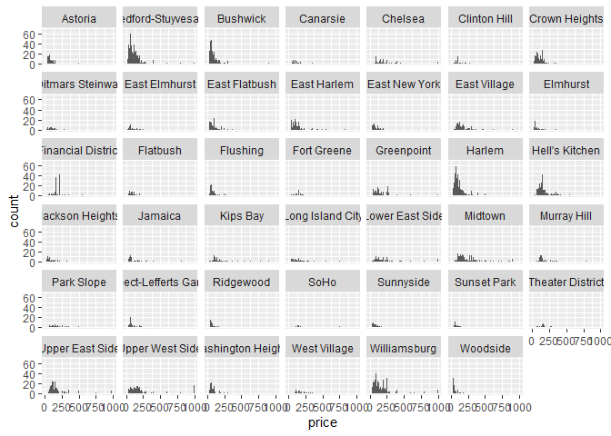

```r
ggplot(data=nycbnb, mapping=aes(x=price))+
  geom_histogram(binwidth=5)+
  facet_wrap(~neighborhood)
```

### Exercise 4

```r
top.5 = nycbnb %>% group_by(neighborhood) %>%
  summarize(median=median(price)) %>%
  arrange(median) %>% slice_tail(n=5)
top.5
```

```
## # A tibble: 5 x 2
##   neighborhood       median
##   <chr>               <dbl>
## 1 Midtown              186
## 2 Financial District   193
## 3 Chelsea              200
## 4 SoHo                 200
## 5 West Village         222.
```

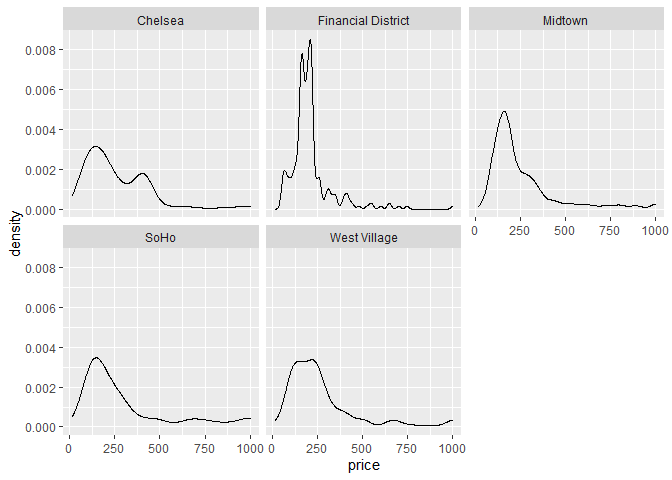

```r
nycbnb %>%
  filter(neighborhood %in% top.5$neighborhood) %>%
  ggplot(mapping=aes(x=price)) + geom_density() +
  facet_wrap(~neighborhood)
```

```r
nycbnb %>%
  filter(neighborhood %in% top.5$neighborhood) %>%
  group_by(neighborhood) %>%
  summarize(minimum=min(price),mean=mean(price),
            standarddev=sd(price),IQR=IQR(price),
            maximum=max(price), n=n())
```

```
## # A tibble: 5 x 7
##   neighborhood       minimum  mean standarddev   IQR maximum     n
##   <chr>                <dbl> <dbl>       <dbl> <dbl>   <dbl> <int>
## 1 Chelsea                 49  260.        183.  265.    1000   328
## 2 Financial District      53  212.        120.   50     1000   242
## 3 Midtown                 41  260.        197.  154     1000   589
## 4 SoHo                    73  305.        256.  205     1000   113
## 5 West Village            15  270.        203.  162.    1000   184
```

The top five median rent neighborhoods are Midtown, Financial District, Chelsea, SoHo, West Village. All neighborhoods have most rents around $200 per night, with a few very high rents. The Financial District is special in that it has less variation becasue there are almost no small and very large rents.

### Exercise 5

The neighborhoods have different numbers of rentals, but the pattern is generally consistent except for the theater district which gets some lower ratings.

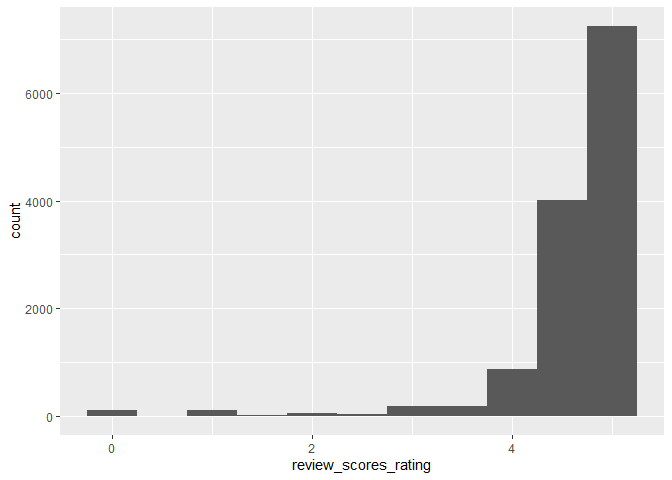

```r
ggplot(data=nycbnb, mapping=aes(x=review_scores_rating))+
  geom_histogram(binwidth=.5)
```

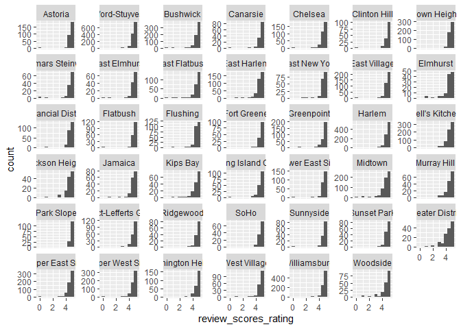

```r
ggplot(data=nycbnb, mapping=aes(x=review_scores_rating))+
  geom_histogram(binwidth=.5)+
  facet_wrap(~neighborhood, scales = 'free_y')
```

### Exercise 6

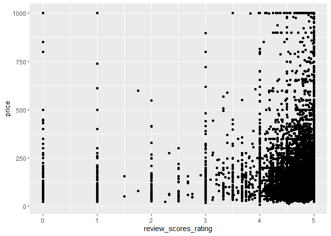

```r
ggplot(data=nycbnb, mapping=aes(x=review_scores_rating, y=price))+
  geom_point()
```

There is a bit of a relationship between price and ratings, but the ratings don’t have much variability. Still, the lowest ratings tend be on the cheaper rentals.

### Exercise 7

(authored by TA: Josh Marvald)

By using just the price variable we don’t take into account that some neighborhoods may have more listings with multiple beds while other neighborhoods may have more listings with just a single bed. This would make the comparisons between neighborhoods skewed because listings with more beds are usually more expensive. A more apt comparison would be to compare prices between neighborhoods while grouping by number of beds so that we are comparing similar properties in different locations.

### Exercise 8 (**extra credit**)

(authored by TA: Josh Marvald)

From the first density plot we can see that when we compared the prices between the 5 more expensive neighborhoods that we were also comparing differing sets of listings in terms of bed count frequencies. For Chelsea, the financial district, and Midtown the listings with more beds have quite different price distributions.The distributions for Soho and the West Village are more as I would’ve expected - unimodal for each bed count with rooms with more beds being generally more expensive.

Moving forward I would probably try to standardize the counts for each number of beds across the neighborhoods in questions to see if the relationship changes between neighborhoods and price and review scores.

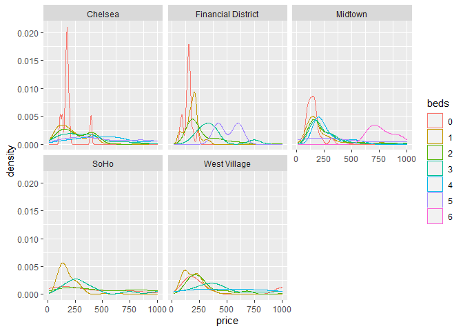

```r
# limiting to top 5 neighborhoods and listings with fewer than 7 beds to better visualize relationships
top5 = top.5 #changing to Josh's data name

nycbnb %>%
  filter(beds < 7) %>%
  mutate(beds = factor(beds)) %>%
  filter(neighborhood %in% top5$neighborhood) %>%
  ggplot(., aes(x = price, color = beds)) +
  geom_density() +
  facet_wrap(vars(neighborhood))
```

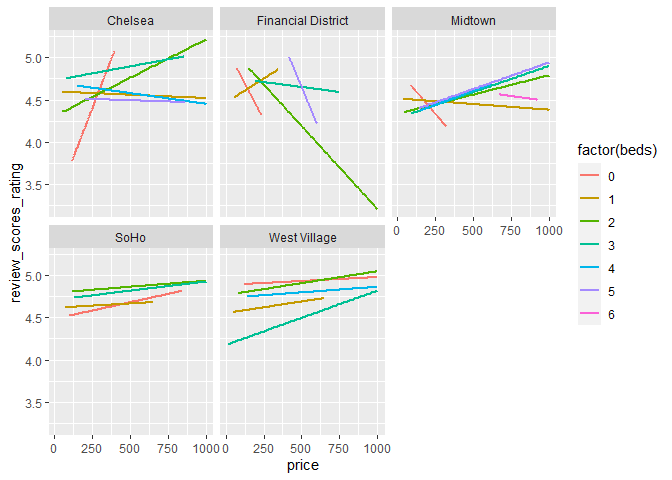

```r
nycbnb %>%
  filter(beds < 7) %>%
  mutate(beds = factor(beds)) %>%
  filter(neighborhood %in% top5$neighborhood) %>%
  ggplot(., aes(x = price, y = review_scores_rating, color = factor(beds))) +
  stat_smooth(method = "lm", se = F) +
  facet_wrap(vars(neighborhood))
```

# Rubric: 26 points total

- 21 points for responses to Ex1-Ex7 @ 3 points per Ex.
- 5 points for consistent and informative commit messages
- Up to 5 points extra credit available for Ex 8. Though it needs to be an excellent answer to get all five points!